# 政治学方法論 I：ロジスティック回帰 (2)

矢内 勇生

December 18, 2014

## 準備

ggplot2を読み込んでおく。

```r
require(ggplot2)
## Mac で日本語を使う場合、以下のコメントを外して実行
# theme_set(theme_gray(base_size=12, base_family="HiraKakuProN-W3"))
```

maxLik パッケージを使うので、インストール済みでない場合はインストールし、読み込む。

```r
if(!require(maxLik)){
    install.packages("maxLik")
    require(maxLik)
}
```

pROC パッケージを使うので、インストール済みでない場合はインストールし、読み込む。

```r
if(!require(pROC)){
    install.packages("pROC")
    require(pROC)
}
```

## 数値計算：アルゴリズムによって最尤推定値を探す

### 二分法 (bisection method)

二分法で最尤推定値 (MLE) $\hat{\theta}$ を求める実践的方法。

$l(\theta)=\log L(\theta)$ とする。

例として、尤度関数 $L(\theta) = \theta^{789} (1-\theta)^{211}$ を考える。 対数尤度は、 $\log L(\theta) = 789 \log \theta + 211 \log (1-\theta)$ である。 この問題については、$S(\theta)=0$ を解くことにより、$\hat{\theta} = 0.789$ であることは簡単にわかるが、あえて二分法で最大値を求めてみよう。

まず、対数尤度関数を定義する。

```r
l.lik.0 <- function(theta){
    l <- 789*log(theta) + 211*log(1 - theta)
    return(l)
}
```

次に、二分法を実行するための関数を用意する。

```r
## 1階微分を計算する関数
df <- function(f, x){
    h <- 0.0001
    d <- (f(x + h) - f(x))/h
    return(d)
}
## 二分法
mle.bisection <- function(theta.l, theta.u, ll, criterion=0.1^10){
    ## 二分法で最尤推定値theta.hatを求める関数
    ## 引数：  theta.l = 最尤推定値の下限
    ##         theta.u = 最尤推定値の上限
    ##         ll = 対数尤度関数
    ##         criterion = 収束の基準（小さいほど正確）
    ## 返り値：theta.hat = 最尤推定値

    counter <- 1  ## 繰り返し回数を表示するためのcounter
    while(TRUE){  ## while ループで操作を繰り返す
        theta.m <- (theta.l + theta.u)/2
        l.lower <- ll(theta.l)
        l.upper <- ll(theta.u)
        l.med <- ll(theta.m)
        first <- df(ll, theta.m)

        if(first==0){
            l.max <- l.med
            break
        }else if(first > 0){
            theta.l <- theta.m
            epsilon <- l.med - l.upper
        }else{
            theta.u <- theta.m
            epsilon <- l.med - l.lower
        }

        ## この時点までにみつけた対数尤度の最大値を表示する
        l.max <- max(c(l.lower, l.med, l.upper))
        cat("Iteration", counter, ": log likelihood =", l.max, "\n")

        ## 基準を満たした時点でループから抜ける
        if(abs(epsilon) < criterion) break
        counter <- counter + 1
    }

    ## 尤度を最大にするthetaの値theta.hat を見つけ、それを返す
    if(l.lower==l.max){
        theta.hat <- theta.l
    }else if(l.med==l.max){
        theta.hat <- theta.m
    }else{
        theta.hat <- theta.u
    }
    return(theta.hat)
}
```

この関数（アルゴリズム）を利用して最尤推定値を求めてみよう。 まず、$\hat{\theta}$ に対する目測が非常に大まかな場合、以下のようになる。

```r
mle.bisection(theta.l=0.1, theta.u=0.9, ll=l.lik.0)
```

```
## Iteration 1 : log likelihood = -568.9749
## Iteration 2 : log likelihood = -535.4548
## Iteration 3 : log likelihood = -515.6517
## Iteration 4 : log likelihood = -515.6517
## Iteration 5 : log likelihood = -515.6517
## Iteration 6 : log likelihood = -515.2853
## Iteration 7 : log likelihood = -515.2853
## Iteration 8 : log likelihood = -515.2853
## Iteration 9 : log likelihood = -515.2786
## Iteration 10 : log likelihood = -515.2786
## Iteration 11 : log likelihood = -515.2786
## Iteration 12 : log likelihood = -515.2786
## Iteration 13 : log likelihood = -515.2786
## Iteration 14 : log likelihood = -515.2786
## Iteration 15 : log likelihood = -515.2786
## Iteration 16 : log likelihood = -515.2786
## Iteration 17 : log likelihood = -515.2786
## Iteration 18 : log likelihood = -515.2786
## Iteration 19 : log likelihood = -515.2786
## Iteration 20 : log likelihood = -515.2786
## Iteration 21 : log likelihood = -515.2786
## Iteration 22 : log likelihood = -515.2786
## Iteration 23 : log likelihood = -515.2786
## Iteration 24 : log likelihood = -515.2786
## Iteration 25 : log likelihood = -515.2786
## Iteration 26 : log likelihood = -515.2786
## Iteration 27 : log likelihood = -515.2786
## Iteration 28 : log likelihood = -515.2786
## Iteration 29 : log likelihood = -515.2786
## Iteration 30 : log likelihood = -515.2786
## Iteration 31 : log likelihood = -515.2786
## Iteration 32 : log likelihood = -515.2786
```

```
## [1] 0.78895
```

このように、32回繰り返しを行った結果、$\hat{\theta} = 0.789$ という「正しい」結果が得られた。

目測（初期値）がもう少し正確な場合、次のようになる。

```r
mle.bisection(theta.l=0.75, theta.u=0.8, ll=l.lik.0)
```

```
## Iteration 1 : log likelihood = -515.6517
## Iteration 2 : log likelihood = -515.2853
## Iteration 3 : log likelihood = -515.2853
## Iteration 4 : log likelihood = -515.2853
## Iteration 5 : log likelihood = -515.2786
## Iteration 6 : log likelihood = -515.2786
## Iteration 7 : log likelihood = -515.2786
## Iteration 8 : log likelihood = -515.2786
## Iteration 9 : log likelihood = -515.2786
## Iteration 10 : log likelihood = -515.2786
## Iteration 11 : log likelihood = -515.2786
## Iteration 12 : log likelihood = -515.2786
## Iteration 13 : log likelihood = -515.2786
## Iteration 14 : log likelihood = -515.2786
## Iteration 15 : log likelihood = -515.2786
## Iteration 16 : log likelihood = -515.2786
## Iteration 17 : log likelihood = -515.2786
## Iteration 18 : log likelihood = -515.2786
## Iteration 19 : log likelihood = -515.2786
## Iteration 20 : log likelihood = -515.2786
## Iteration 21 : log likelihood = -515.2786
## Iteration 22 : log likelihood = -515.2786
## Iteration 23 : log likelihood = -515.2786
## Iteration 24 : log likelihood = -515.2786
## Iteration 25 : log likelihood = -515.2786
## Iteration 26 : log likelihood = -515.2786
## Iteration 27 : log likelihood = -515.2786
## Iteration 28 : log likelihood = -515.2786
```

```
## [1] 0.78895
```

得られる結果は先ほどと同じ（criterion を変えていないので）だが、繰り返し回数が減った。

### ニュートン-ラフソン法 (Newton-Raphson Method)

ニュートン・ラフソン法で最尤推定値 (MLE) $\hat{\theta}$ を求める実践的方法。

1. 対数尤度関数をグラフにし、$\hat{\theta}$が大体どのあたりにあるか、予測する。
2. 予測した値を初期値$\theta$とする
3. $\bar{\theta} \leftarrow \theta$ とおき、次のように$\theta$を更新する： $\theta \leftarrow \bar{\theta} - \frac{l'(\bar{\theta})}{l''(\bar{\theta})}$
4. 3に戻って操作を繰り返し、$|\theta - \bar{\theta}| < \delta$になった時点で操作を止める。
- 長所：収束が速い
- 短所：必ず最大値を見つけるとは限らない

例として、先ほどと同じ関数の最尤推定値を求めよう。 まず、アルゴリズムを作る。

```r
## 二階微分を計算する関数
## 一階微分の関数 df を利用
ddf <- function(f, x){
    h <- -0.0001
    return((df(f, x+h) - df(f, x))/h)
}
newton.mle <- function(ll, delta=0.1^12, theta.0) {
    h <- 0.001
    theta.bar <- theta.0
    counter <- 1
    while(TRUE) {
        first <- df(ll, theta.bar)
        second <- ddf(ll, theta.bar)
        theta.0 <- theta.bar - first/second

        ## この時点までにみつけた対数尤度の最大値を表示する
        l.max <- ll(theta.0)
        cat("Iteration", counter, ": log likelihood =", l.max, "\n")

        ## 基準を満たした時点でループから抜ける
        if (abs(theta.0 - theta.bar) < delta) break

        theta.bar <- theta.0
        counter = counter + 1
    }
    return(theta.0)
}
```

このアルゴリズムで、最尤推定値を求めてみよう。 初期値は0.5にしてみる。

```r
newton.mle(l.lik.0, theta.0=0.5)
```

```
## Iteration 1 : log likelihood = -515.2786
## Iteration 2 : log likelihood = -515.2786
## Iteration 3 : log likelihood = -515.2786
```

```
## [1] 0.78895
```

先ほどと同様の結果が、先ほどより速く得られることがわかる。

#### 母数が2つ以上の場合

母数が2変数以上の場合も同様のアルゴリズムで最大値を探すことができるが、プログラムが少々面倒なので、既存の関数を使おう。 最尤推定値を求める場合には、**maxLik** パッケージの`maxLik()`を利用すればよい。 必要な引数は、対数尤度関数と、推定の初期値、使用する方法である。 対数尤度関数は、第1引数が母数ベクトルになるように設定する。 また、推定の初期値 (start) には、母数ベクトルと同じ長さの数値ベクトルを渡す。 ニュートン・ラフソン法を使うには、`method="NR"`とする。 実際に使ってみよう。

```r
maxLik(l.lik.0, start=0.5, method="NR")
```

```
## Maximum Likelihood estimation
## Newton-Raphson maximisation, 2 iterations
## Return code 1: gradient close to zero
## Log-Likelihood: -515.2786 (1 free parameter(s))
## Estimate(s): 0.789
```

このように、$\theta =0.5$というあまり正確でない値から出発しても、素早く（繰り返しは2回！）最尤推定値を求めることができる。

## ロジスティック回帰

### 例1：過去の当選回数で当選確率を予測する

[浅野・矢内 (2013)](http://www2.kobe-u.ac.jp/~yyanai/jp/quant-methods-stata/) の第14章に登場する架空のデータ（ml_wl.dta）を利用して説明する。

使用するデータを読み込む。

```r
require(foreign)
myd <- read.dta("data/ml_wl.dta")
```

このデータを使い、自民党候補の小選挙区における当落 (wlsmd) を縦軸に、それまでの当選回数 (previous) を横軸にした散布図を表示してみよう。

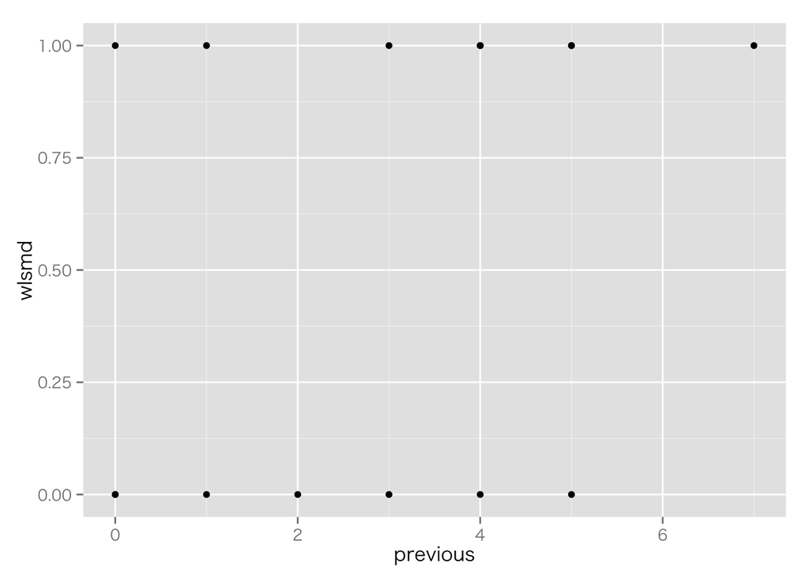

```r
p1 <- ggplot(myd, aes(previous, wlsmd)) + geom_point()
print(p1)
```

このデータを使い、当落を応答変数、過去の当選回数を説明変数として、ロジスティック回帰分析を行おう。 ここでは、`glm()` を使わず、自分で尤度関数を定義して最尤推定値を求めてみよう。 まず、対数尤度関数（講義スライドを参照）を定義する。 `maxLik()` で最尤推定値を求めるために、関数の第1引数は母数ベクトルにする。

```r
terms <- 0:7
n.cand <- c(3, 2, 1, 2, 3, 3, 0, 1)
y <- c(1, 1, 0, 1, 2, 2, 0, 1)
ll.1 <- function(beta){
    N <- length(y)
    beta1 <- beta[1]
    beta2 <- beta[2]
    ll.vec <- rep(NA, N)
    for(i in 1:N){
        prob <- 1/(1 + exp(-beta1 - beta2*terms[i]))
        l <- prob^y[i] * (1 - prob)^(n.cand[i] - y[i])
        ll.vec[i] <- log(l)
    }
    ll <- sum(ll.vec)
    return(ll)
}
```

この対数尤度関数を使い、最尤推定値を求めよう。 推定する母数は2つあるので、初期値には長さ2の数値ベクトルを与える。

```r
fit.01 <- maxLik(ll.1, start=c(0, 1), method="NR")
summary(fit.01)
```

```
## --------------------------------------------
## Maximum Likelihood estimation
## Newton-Raphson maximisation, 5 iterations
## Return code 1: gradient close to zero
## Log-Likelihood: -9.404832
## 2  free parameters
## Estimates:
##      Estimate Std. error t value Pr(> t)
## [1,] -0.90945    0.96433 -0.9431  0.3456
## [2,]  0.36210    0.27850  1.3002  0.1935
## --------------------------------------------
```

これで最尤推定値、$\hat{\beta}_1 \approx -0.91$、$\hat{\beta}_2 \approx 0.36$を求めることができた。

AICを求めると、

```r
-2 * summary(fit.01)$loglik + 2 * 2
```

```
## [1] 22.80966
```

となる。

念のため、`glm()` で同じ結果が得られるか確かめてみよう。

```r
fit.1 <- glm(wlsmd ~ previous, data=myd, family=binomial(link="logit"))
summary(fit.1)
```

```
##
## Call:
## glm(formula = wlsmd ~ previous, family = binomial(link = "logit"),
##     data = myd)
##
## Deviance Residuals:
##     Min       1Q   Median       3Q      Max
## -1.5760  -1.0276   0.5995   0.9587   1.5798
##
## Coefficients:
##             Estimate Std. Error z value Pr(>|z|)
## (Intercept)  -0.9095     0.9636  -0.944    0.345
## previous      0.3621     0.2784   1.301    0.193
##
## (Dispersion parameter for binomial family taken to be 1)
##
##     Null deviance: 20.728  on 14  degrees of freedom
## Residual deviance: 18.810  on 13  degrees of freedom
## AIC: 22.81
##
## Number of Fisher Scoring iterations: 4
```

このように、同じ結果が得られる。

次に、予測の正解率を求める。 そのために、まず予測値（予測確率）を求める。

```r
predicted.1 <- predict(fit.1, type="response")
```

この予測値を使い、「当選確率0.5以上を当選」と予測した場合の正解率を計算してみよう。

```r
err.rate.1 <- mean((predicted.1 >= 0.5 & myd$wlsmd==0) |
                   (predicted.1 < 0.5 & myd$wlsmd==1))
1 - err.rate.1
```

```
## [1] 0.6666667
```

よって、正解率は67%であることがわかる。 完全に当てずっぽうでも50%は当たるはずなので、正解率があまりいいとはいえない。

最後に、ROC曲線を描いてみよう。 ROC曲線は、**pROC**パッケージの`roc()`を利用して描くことができる。

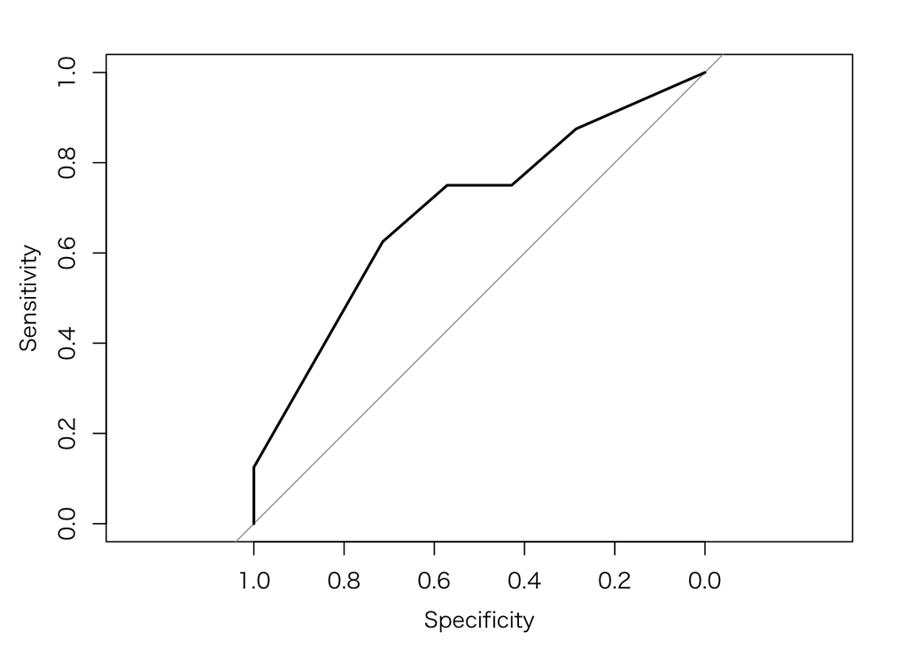

```
##
## Call:
## roc.formula(formula = myd$wlsmd ~ predicted.1, plot = TRUE)
##
## Data: predicted.1 in 7 controls (myd$wlsmd 0) < 8 cases (myd$wlsmd 1).
## Area under the curve: 0.6964
```

```r
roc(myd$wlsmd ~ predicted.1, plot=TRUE)
```

このモデルは、結果の予測にあまり役立っていないことがわかる。 ROC曲線の下にある面積は0.69であり、基準となる0.5と比べてあまり改善していない。

### 例2：選挙費用で当選確率を予測する

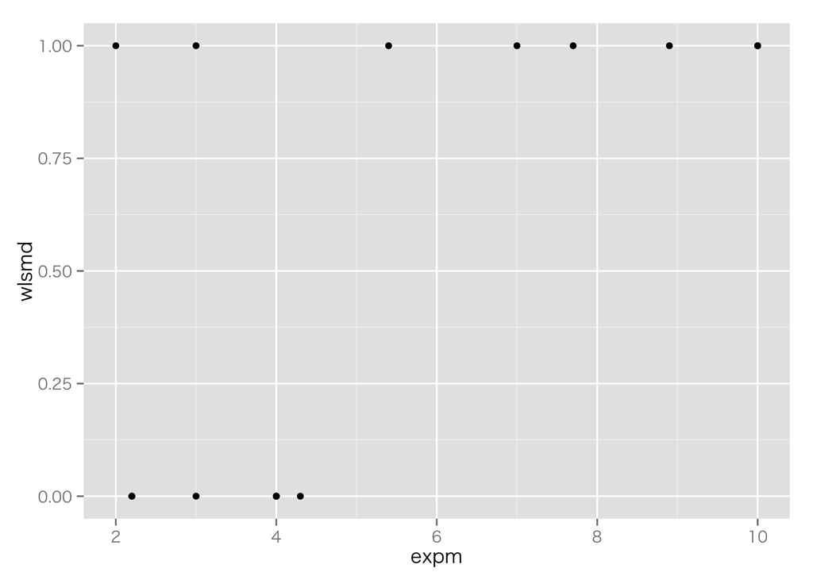

```r
p2 <- ggplot(myd, aes(expm, wlsmd)) + geom_point()
print(p2)
```

```r
r <- myd$wlsmd
x <- myd$expm
ll.2 <- function(beta){
    N <- length(r)
    beta1 <- beta[1]
    beta2 <- beta[2]
    ll.vec <- rep(NA, N)
    for(i in 1:N){
        prob <- 1/(1 + exp(-beta1 - beta2*x[i]))
        l <- prob^r[i] * (1 - prob)^(1 - r[i])
        ll.vec[i] <- log(l)
    }
    ll <- sum(ll.vec)
    return(ll)
}
```

この対数尤度関数を使い、最尤推定値を求めよう。 推定する母数は2つあるので、初期値には長さ2の数値ベクトルを与える。

```r
fit.02 <- maxLik(ll.2, start=c(0, .5), method="NR")
summary(fit.02)
```

```
## --------------------------------------------
## Maximum Likelihood estimation
## Newton-Raphson maximisation, 6 iterations
## Return code 1: gradient close to zero
## Log-Likelihood: -6.925697
## 2  free parameters
## Estimates:
##      Estimate Std. error t value Pr(> t)
## [1,] -3.18110    1.72072 -1.8487 0.06450
## [2,]  0.70456    0.37974  1.8553 0.06355
## --------------------------------------------
```

よって、$\hat{\beta}_1 \approx -3.18$、$\hat{\beta}_2 \approx 0.70$を求めることができた。

AICを求めると、

```r
-2 * summary(fit.02)$loglik + 2 * 2
```

```
## [1] 17.85139
```

となる。

念のため、`glm()` で同じ結果が得られるか確かめてみよう。

```r
fit.2 <- glm(wlsmd ~ expm, data=myd, family=binomial(link="logit"))
summary(fit.2)
```

```
##
## Call:
## glm(formula = wlsmd ~ expm, family = binomial(link = "logit"),
##     data = myd)
##
## Deviance Residuals:
##     Min       1Q   Median       3Q      Max
## -1.1138  -0.8983   0.2037   0.5074   1.9642
##
## Coefficients:
##             Estimate Std. Error z value Pr(>|z|)
## (Intercept)  -3.1811     1.7219  -1.847   0.0647
## expm          0.7046     0.3800   1.854   0.0637
##
## (Dispersion parameter for binomial family taken to be 1)
##
##     Null deviance: 20.728  on 14  degrees of freedom
## Residual deviance: 13.851  on 13  degrees of freedom
## AIC: 17.851
##
## Number of Fisher Scoring iterations: 5
```

このように、同じ結果が得られる。

次に、予測の正解率を求める。 そのために、まず予測値（予測確率）を求める。

```r
predicted.2 <- predict(fit.2, type="response")
```

この予測値を使い、「当選確率0.5以上を当選」と予測した場合の正解率を計算してみよう。

```r
err.rate.2 <- mean((predicted.2 >= 0.5 & myd$wlsmd==0) |
                   (predicted.2 < 0.5 & myd$wlsmd==1))
1 - err.rate.2
```

```
## [1] 0.8666667
```

よって、正解率は87%であることがわかる。正解率は、かなりよいようだ。

最後に、ROC曲線を描いてみよう。

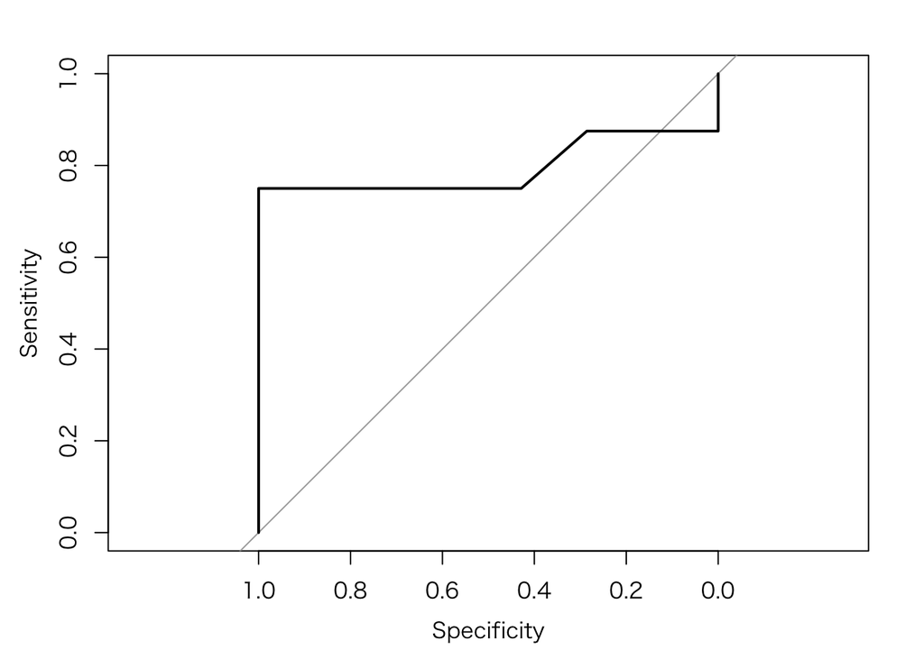

```
##
## Call:
## roc.formula(formula = myd$wlsmd ~ predicted.2, plot = TRUE)
##
## Data: predicted.2 in 7 controls (myd$wlsmd 0) < 8 cases (myd$wlsmd 1).
## Area under the curve: 0.7946
```

```r
roc(myd$wlsmd ~ predicted.2, plot=TRUE)
```

ROC曲線の下側の面積は0.79であり、先ほどのモデルよりは、予測がうまく行えているようだ。

授業の内容に戻る